# CreditRiskData

```python
import warnings
warnings.filterwarnings('ignore')
```

```python
import numpy as np
import pandas as pd
CreditRiskData = pd.read_csv(filepath_or_buffer="C:/Users/laksh/Python/Python IVY Feb-2024/Python Datasets/Classification Datasets/CreditRiskData.csv",delimiter=",")
CreditRiskData.head()
```

|  | GoodCredit | checkingstatus1 | duration2 | history3 | purpose4 | amount5 | savings6 | employ7 | installment8 | status9 | ... | residence11 | property12 | age13 | otherplans14 | housing15 | cards16 | job17 | liable18 | tele19 | foreign20 |
| --- | --- | --- | --- | --- | --- | --- | --- | --- | --- | --- | --- | --- | --- | --- | --- | --- | --- | --- | --- | --- | --- |
| 0 | 0 | A11 | 6 | A34 | A43 | 1169 | A65 | A75 | 4 | A93 | ... | 4 | A121 | 67 | A143 | A152 | 2 | A173 | 1 | A192 | A201 |
| 1 | 1 | A12 | 48 | A32 | A43 | 5951 | A61 | A73 | 2 | A92 | ... | 2 | A121 | 22 | A143 | A152 | 1 | A173 | 1 | A191 | A201 |
| 2 | 0 | A14 | 12 | A34 | A46 | 2096 | A61 | A74 | 2 | A93 | ... | 3 | A121 | 49 | A143 | A152 | 1 | A172 | 2 | A191 | A201 |
| 3 | 0 | A11 | 42 | A32 | A42 | 7882 | A61 | A74 | 2 | A93 | ... | 4 | A122 | 45 | A143 | A153 | 1 | A173 | 2 | A191 | A201 |
| 4 | 1 | A11 | 24 | A33 | A40 | 4870 | A61 | A73 | 3 | A93 | ... | 4 | A124 | 53 | A143 | A153 | 2 | A173 | 2 | A191 | A201 |

5 rows × 21 columns

### Problem statement: Predict if a load application can be approved or not based on its characteristics like what is the duration, purpose and amount of loan

```python
CreditRiskData.info()
```

```
<class 'pandas.core.frame.DataFrame'>
RangeIndex: 1000 entries, 0 to 999
Data columns (total 21 columns):
 #   Column           Non-Null Count  Dtype
---  ------           --------------  -----
 0   GoodCredit       1000 non-null   int64
 1   checkingstatus1  1000 non-null   object
 2   duration2        1000 non-null   int64
 3   history3         1000 non-null   object
 4   purpose4         1000 non-null   object
 5   amount5          1000 non-null   int64
 6   savings6         1000 non-null   object
 7   employ7          1000 non-null   object
 8   installment8     1000 non-null   int64
 9   status9          1000 non-null   object
 10  others10         1000 non-null   object
 11  residence11      1000 non-null   int64
 12  property12       1000 non-null   object
 13  age13            1000 non-null   int64
 14  otherplans14     1000 non-null   object
 15  housing15        1000 non-null   object
 16  cards16          1000 non-null   int64
 17  job17            1000 non-null   object
 18  liable18         1000 non-null   int64
 19  tele19           1000 non-null   object
 20  foreign20        1000 non-null   object
dtypes: int64(8), object(13)
memory usage: 164.2+ KB
```

```python
CreditRiskData.describe(include='all')
```

|  | GoodCredit | checkingstatus1 | duration2 | history3 | purpose4 | amount5 | savings6 | employ7 | installment8 | status9 | ... | residence11 | property12 | age13 | otherplans14 | housing15 | cards16 | job17 | liable18 | tele19 | foreign20 |
| --- | --- | --- | --- | --- | --- | --- | --- | --- | --- | --- | --- | --- | --- | --- | --- | --- | --- | --- | --- | --- | --- |
| count | 1000.000000 | 1000 | 1000.000000 | 1000 | 1000 | 1000.000000 | 1000 | 1000 | 1000.000000 | 1000 | ... | 1000.000000 | 1000 | 1000.000000 | 1000 | 1000 | 1000.000000 | 1000 | 1000.000000 | 1000 | 1000 |
| unique | NaN | 4 | NaN | 5 | 10 | NaN | 5 | 5 | NaN | 4 | ... | NaN | 4 | NaN | 3 | 3 | NaN | 4 | NaN | 2 | 2 |
| top | NaN | A14 | NaN | A32 | A43 | NaN | A61 | A73 | NaN | A93 | ... | NaN | A123 | NaN | A143 | A152 | NaN | A173 | NaN | A191 | A201 |
| freq | NaN | 394 | NaN | 530 | 280 | NaN | 603 | 339 | NaN | 548 | ... | NaN | 332 | NaN | 814 | 713 | NaN | 630 | NaN | 596 | 963 |
| mean | 0.300000 | NaN | 20.903000 | NaN | NaN | 3271.258000 | NaN | NaN | 2.973000 | NaN | ... | 2.845000 | NaN | 35.546000 | NaN | NaN | 1.407000 | NaN | 1.155000 | NaN | NaN |
| std | 0.458487 | NaN | 12.058814 | NaN | NaN | 2822.736876 | NaN | NaN | 1.118715 | NaN | ... | 1.103718 | NaN | 11.375469 | NaN | NaN | 0.577654 | NaN | 0.362086 | NaN | NaN |
| min | 0.000000 | NaN | 4.000000 | NaN | NaN | 250.000000 | NaN | NaN | 1.000000 | NaN | ... | 1.000000 | NaN | 19.000000 | NaN | NaN | 1.000000 | NaN | 1.000000 | NaN | NaN |
| 25% | 0.000000 | NaN | 12.000000 | NaN | NaN | 1365.500000 | NaN | NaN | 2.000000 | NaN | ... | 2.000000 | NaN | 27.000000 | NaN | NaN | 1.000000 | NaN | 1.000000 | NaN | NaN |
| 50% | 0.000000 | NaN | 18.000000 | NaN | NaN | 2319.500000 | NaN | NaN | 3.000000 | NaN | ... | 3.000000 | NaN | 33.000000 | NaN | NaN | 1.000000 | NaN | 1.000000 | NaN | NaN |
| 75% | 1.000000 | NaN | 24.000000 | NaN | NaN | 3972.250000 | NaN | NaN | 4.000000 | NaN | ... | 4.000000 | NaN | 42.000000 | NaN | NaN | 2.000000 | NaN | 1.000000 | NaN | NaN |
| max | 1.000000 | NaN | 72.000000 | NaN | NaN | 18424.000000 | NaN | NaN | 4.000000 | NaN | ... | 4.000000 | NaN | 75.000000 | NaN | NaN | 4.000000 | NaN | 2.000000 | NaN | NaN |

11 rows × 21 columns

```python
CreditRiskData.nunique()
```

```
GoodCredit           2
checkingstatus1      4
duration2           33
history3             5
purpose4            10
amount5            921
savings6             5
employ7              5
installment8         4
status9              4
others10             3
residence11          4
property12           4
age13               53
otherplans14         3
housing15            3
cards16              4
job17                4
liable18             2
tele19               2
foreign20            2
dtype: int64
```

```python
CreditRiskData.columns
```

```
Index(['GoodCredit', 'checkingstatus1', 'duration2', 'history3', 'purpose4',
       'amount5', 'savings6', 'employ7', 'installment8', 'status9', 'others10',
       'residence11', 'property12', 'age13', 'otherplans14', 'housing15',
       'cards16', 'job17', 'liable18', 'tele19', 'foreign20'],
      dtype='object')
```

# Data description

The business meaning of each column in the data is as below

- GoodCredit: Whether the issued loan was a good decision or bad
- checkingstatus: Status of existing checking account.
- duration: Duration of loan in months
- history: Credit history of the applicant
- purpose: Purpose for the loan
- amount: Credit amount
- savings: Savings account/bonds
- employ: Present employment since
- installment: Installment rate in percentage of disposable income
- status: Personal status and sex
- others: Other debtors / guarantors for the applicant
- residence: Present residence since
- property: Property type of applicant
- age: Age in years
- otherplans: Other installment plans
- housing: Housing
- cards: Number of existing credits at this bank
- job: Job
- liable: Number of people being liable to provide maintenance for
- tele: Is the Telephone registered or not
- foreign: Is the applicant a foreign worker

## Data Description

- **GoodCredit** : This is the Target Variable. Categorical
- **checkingstatus1** : Categorical Variable
- **duration2** : Continuous Variable
- **history3** : Categorical Variable
- **purpose4** : Categorical Variable
- **amount5** : Continuous Variable
- **savings6** : Categorical Variable
- **employ7** : Categorical Variable
- **installment8** : Categorical Variable
- **status9** : Categorical Variable
- **others10** : Categorical Variable
- **residence11** : Categorical Variable
- **property12** : Categorical Variable
- **age13** : Continuous Variable
- **otherplans14** : Categorical Variable
- **housing15** : Categorical Variable
- **cards16** : Categorical Variable
- **job17** : Categorical Variable
- **liable18** : Categorical Variable
- **tele19** : Categorical Variable
- **foreign20** : Categorical Variable

## Choosing the Method for ML Model

Since the Target Variable is Categorical, we would have to conduct Supervised ML - Classification

## Analysis of Target Variable

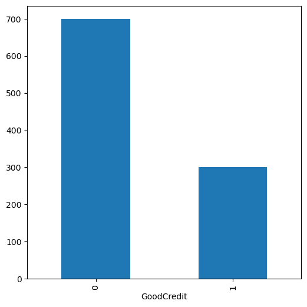

```python
%matplotlib inline
GroupedData =  CreditRiskData.groupby('GoodCredit').size()
GroupedData.plot(kind= 'bar', figsize= (6,6))
```

```python
import re

# Trimming digits from the column names
CreditRiskData.columns = [re.sub(r'\d+', '', col) for col in CreditRiskData.columns]

# Printing the new column names
print(CreditRiskData.columns)
```

```
Index(['GoodCredit', 'checkingstatus', 'duration', 'history', 'purpose',
       'amount', 'savings', 'employ', 'installment', 'status', 'others',
       'residence', 'property', 'age', 'otherplans', 'housing', 'cards', 'job',
       'liable', 'tele', 'foreign'],
      dtype='object')
```

# Univariate Analysis

- Categorical - Bar
- Continuous - Histogram

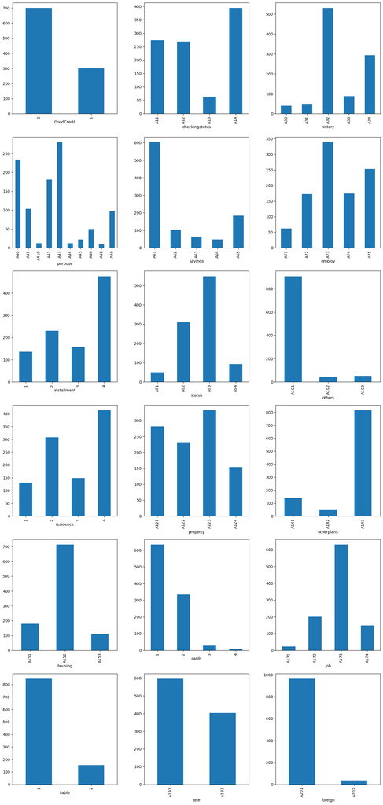

```python
def plotabarcharts(inpData, CatColslist):
    import matplotlib.pyplot as plt
    import math

    # Calculate the grid size
    n_cols = 3  # Number of columns in the subplot grid
    n_rows = math.ceil(len(CatColslist) / n_cols)  # Number of rows based on the number of columns

    # Create the subplots with increased size and spacing
    fig, subplots = plt.subplots(nrows=n_rows, ncols=n_cols, figsize=(15, 5 * n_rows))
    fig.tight_layout(pad=4.0)  # Adjust spacing between subplots

    for Colname, ax in zip(CatColslist, subplots.flatten()):  # Flatten the grid to easily iterate
        inpData.groupby(Colname).size().plot(kind='bar', ax=ax)


    plt.show()

# List of categorical columns
ColList = ['GoodCredit', 'checkingstatus', 'history', 'purpose', 'savings', 'employ', 'installment',
           'status', 'others', 'residence', 'property', 'otherplans', 'housing', 'cards', 'job',
           'liable', 'tele', 'foreign']

# Call the function with the DataFrame and column list
plotabarcharts(CreditRiskData, ColList)
```

###### All Columns Are Selected: Doubts on foreign, Others, cards, Otherplans

```
array([[<Axes: title={'center': 'duration'}>,
        <Axes: title={'center': 'amount'}>],
       [<Axes: title={'center': 'age'}>, <Axes: >]], dtype=object)
```

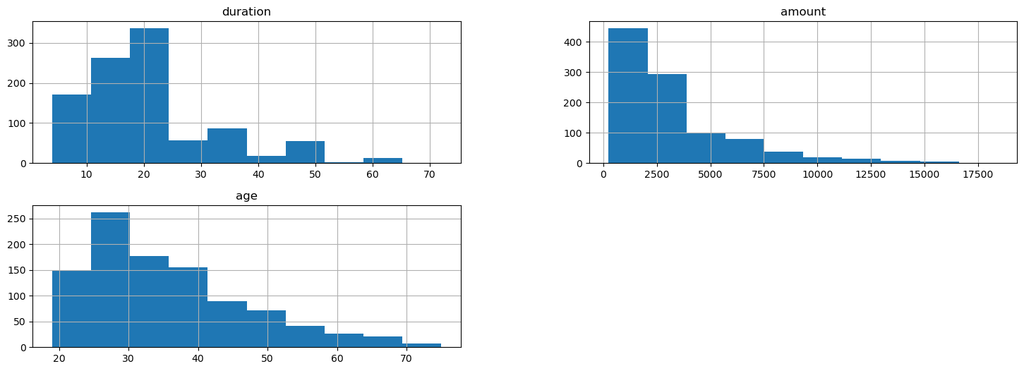

```python
CreditRiskData.hist(column=['duration','amount','age'], figsize = (18,6))
```

#### Outlier Treatment - Not Needed as the Histograms are skewed

# Missing Values Treatment

```python
CreditRiskData.isnull().sum()
```

```
GoodCredit        0
checkingstatus    0
duration          0
history           0
purpose           0
amount            0
savings           0
employ            0
installment       0
status            0
others            0
residence         0
property          0
age               0
otherplans        0
housing           0
cards             0
job               0
liable            0
tele              0
foreign           0
dtype: int64
```

## Bivariate Analysis

- Countinuous Variable Vs Countinuous Variable - Scatter Plot
- Countinuous Variable Vs Categorical Variable - Box Plot
- Categorical Variable Vs Categorical Variable - Grouped Bar

## Statistical Analysis

- Countinuous Variable Vs Countinuous Variable - Correlation Value
- Countinuous Variable Vs Categorical Variable - Annova Test
- Categorical Variable Vs Categorical Variable - Chi2 Test

```python
CreditRiskData.columns
```

```
Index(['GoodCredit', 'checkingstatus', 'duration', 'history', 'purpose',
       'amount', 'savings', 'employ', 'installment', 'status', 'others',
       'residence', 'property', 'age', 'otherplans', 'housing', 'cards', 'job',
       'liable', 'tele', 'foreign'],
      dtype='object')
```

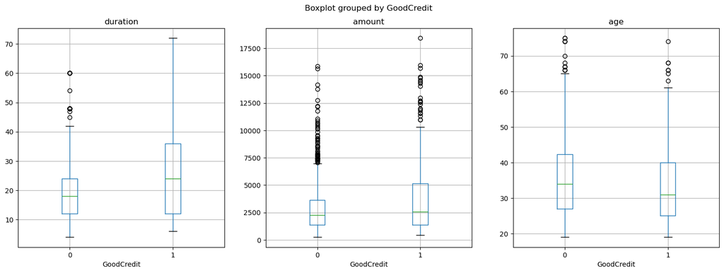

```python
ColsToPlot = ['duration', 'amount', 'age']

def plotboxchart(inpData, TarVar, Predcols):
    import matplotlib.pyplot as plt
    fig, subplots = plt.subplots(nrows = 1, ncols = len(Predcols),figsize = (18,6))

    for predictors, prednum in zip(Predcols, range(len(Predcols))):
        inpData.boxplot(column= predictors, by= TarVar, figsize = (6,6),vert=True ,ax= subplots[prednum])

plotboxchart(CreditRiskData, 'GoodCredit', ColsToPlot)
```

#### Charts are insuffiecient to reject a column- Annova test shall help to conclude

```python
def annovatest(inpData, TarVar, predCols):
    from scipy.stats import f_oneway

    selectedpreds = []

    for cols in predCols:
        GroupedData = inpData.groupby(TarVar)[cols].apply(list)
        AnnovaResults = f_oneway(*GroupedData)

        if AnnovaResults[1] < 0.05:
            print(f'{cols} is correlated with {TarVar} with p-Value - {AnnovaResults[1]}')
            selectedpreds.append(cols)

        else:
            print(f'{cols} is correlated NOT with {TarVar} with p-Value - {AnnovaResults[1]}')

    return selectedpreds
```

```python
annovatest(CreditRiskData, 'GoodCredit',ColsToPlot)
```

```
duration is correlated with GoodCredit with p-Value - 6.488049877187189e-12
amount is correlated with GoodCredit with p-Value - 8.797572373533373e-07
age is correlated with GoodCredit with p-Value - 0.003925339398278295
```

```
['duration', 'amount', 'age']
```

```python
def plotgroupedBars(inpData, TarVar, Preds):
    import matplotlib.pyplot as plt
    import math

    ncols = 3
    nrows = math.ceil(len(Preds)/ncols)
    fig, subplots = plt.subplots(nrows= nrows, ncols=ncols, figsize=(nrows*6,80))
    subplots = subplots.flatten()


    for pred, i in zip(Preds, subplots):
        crosstabres = pd.crosstab(index= inpData[pred], columns=inpData[TarVar])
        crosstabres.plot.bar(color= ('red','green'), ax= i, title= pred + ' '+ 'Vs' +' '+ TarVar)
```

```python
CreditRiskData.columns
```

```
Index(['GoodCredit', 'checkingstatus', 'duration', 'history', 'purpose',
       'amount', 'savings', 'employ', 'installment', 'status', 'others',
       'residence', 'property', 'age', 'otherplans', 'housing', 'cards', 'job',
       'liable', 'tele', 'foreign'],
      dtype='object')
```

```python
ColList = ['checkingstatus', 'history', 'purpose', 'savings', 'employ', 'installment', 'status', 'others', 'residence', 'property', 'otherplans', 'housing', 'cards', 'job', 'liable', 'tele', 'foreign']
```

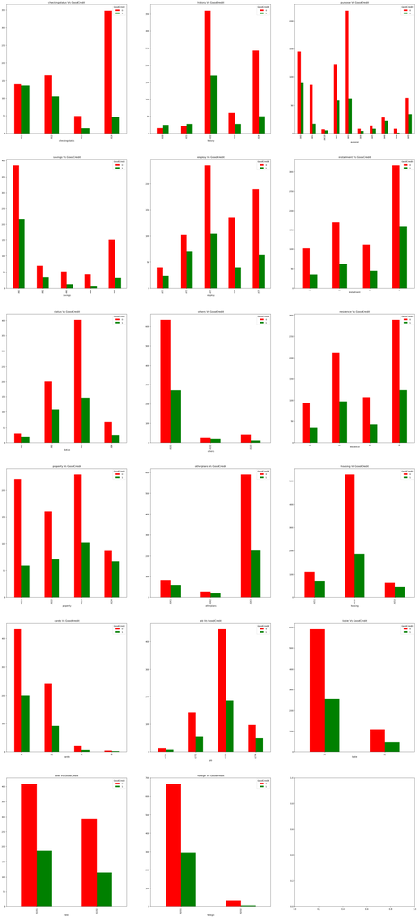

```python
plotgroupedBars(CreditRiskData, 'GoodCredit', ColList)
```

```python
def functionchi2(inpData, TarVar, Preds):
    from scipy.stats import chi2_contingency

    SelectedPreds = []

    for predictor in Preds:
        Crosstab = pd.crosstab(index= inpData[predictor], columns=inpData[TarVar])
        chi2res = chi2_contingency(Crosstab)

        if chi2res[1] < 0.05:
            print(f'{predictor} is correlated with {TarVar} with p-Value - {chi2res[1]}')
            SelectedPreds.append(predictor)

        else:
            print(f'{predictor} is correlated NOT with {TarVar} with p-Value - {chi2res[1]}')

    return SelectedPreds
```

```python
functionchi2(CreditRiskData, 'GoodCredit', ColList)
```

```
checkingstatus is correlated with GoodCredit with p-Value - 1.2189020722893845e-26
history is correlated with GoodCredit with p-Value - 1.2791872956750918e-12
purpose is correlated with GoodCredit with p-Value - 0.00011574910079691542
savings is correlated with GoodCredit with p-Value - 2.761214238568249e-07
employ is correlated with GoodCredit with p-Value - 0.001045452349140254
installment is correlated NOT with GoodCredit with p-Value - 0.1400333122128481
status is correlated with GoodCredit with p-Value - 0.02223800546926877
others is correlated with GoodCredit with p-Value - 0.036055954027247226
residence is correlated NOT with GoodCredit with p-Value - 0.8615521320413175
property is correlated with GoodCredit with p-Value - 2.8584415733250017e-05
otherplans is correlated with GoodCredit with p-Value - 0.0016293178186473534
housing is correlated with GoodCredit with p-Value - 0.00011167465374597684
cards is correlated NOT with GoodCredit with p-Value - 0.4451440800083001
job is correlated NOT with GoodCredit with p-Value - 0.5965815918843431
liable is correlated NOT with GoodCredit with p-Value - 1.0
tele is correlated NOT with GoodCredit with p-Value - 0.27887615430357426
foreign is correlated with GoodCredit with p-Value - 0.015830754902852885
```

```
['checkingstatus',
 'history',
 'purpose',
 'savings',
 'employ',
 'status',
 'others',
 'property',
 'otherplans',
 'housing',
 'foreign']
```

```python
colselected = ['checkingstatus', 'history', 'purpose', 'savings', 'employ', 'status', 'others', 'property', 'otherplans', 'housing', 'foreign','duration', 'amount', 'age']
DataForML = CreditRiskData[colselected]
DataForML['GoodCredit'] = CreditRiskData['GoodCredit']
DataForML.head()
```

|  | checkingstatus | history | purpose | savings | employ | status | others | property | otherplans | housing | foreign | duration | amount | age | GoodCredit |
| --- | --- | --- | --- | --- | --- | --- | --- | --- | --- | --- | --- | --- | --- | --- | --- |
| 0 | A11 | A34 | A43 | A65 | A75 | A93 | A101 | A121 | A143 | A152 | A201 | 6 | 1169 | 67 | 0 |
| 1 | A12 | A32 | A43 | A61 | A73 | A92 | A101 | A121 | A143 | A152 | A201 | 48 | 5951 | 22 | 1 |
| 2 | A14 | A34 | A46 | A61 | A74 | A93 | A101 | A121 | A143 | A152 | A201 | 12 | 2096 | 49 | 0 |
| 3 | A11 | A32 | A42 | A61 | A74 | A93 | A103 | A122 | A143 | A153 | A201 | 42 | 7882 | 45 | 0 |
| 4 | A11 | A33 | A40 | A61 | A73 | A93 | A101 | A124 | A143 | A153 | A201 | 24 | 4870 | 53 | 1 |

```python
DataForML.nunique()
```

```
checkingstatus      4
history             5
purpose            10
savings             5
employ              5
status              4
others              3
property            4
otherplans          3
housing             3
foreign             2
duration           33
amount            921
age                53
GoodCredit          2
dtype: int64
```

## Treating Ordered Data

```python
def sort_and_replace_with_numbers(df, columns):
    mapping_dict = {}  # Dictionary to store mappings for each column
    for column_name in columns:
        # Get the unique values from the column and sort them
        unique_values = sorted(df[column_name].unique())

        # Create a dictionary that maps each unique value to a number
        value_to_number = {value: i for i, value in enumerate(unique_values)}

        # Replace the values in the column with the corresponding numbers
        df[column_name].replace(value_to_number, inplace=True)

        # Store the mapping in the mapping_dict for reference
        mapping_dict[column_name] = value_to_number

    return df, mapping_dict  # Return the modified DataFrame and the mapping dictionary

# Example usage:
Replace_cols = ['checkingstatus', 'history', 'purpose', 'savings', 'employ', 'status', 'others',
               'property', 'otherplans', 'housing', 'foreign']

DataForML, mappings = sort_and_replace_with_numbers(DataForML, Replace_cols)

# Display the mapping dictionary for all columns
print("Mapping of original values to numbers for all columns:", mappings)

# Display the modified DataFrame
print(DataForML.head())
```

```
Mapping of original values to numbers for all columns: {'checkingstatus': {'A11': 0, 'A12': 1, 'A13': 2, 'A14': 3}, 'history': {'A30': 0, 'A31': 1, 'A32': 2, 'A33': 3, 'A34': 4}, 'purpose': {'A40': 0, 'A41': 1, 'A410': 2, 'A42': 3, 'A43': 4, 'A44': 5, 'A45': 6, 'A46': 7, 'A48': 8, 'A49': 9}, 'saving…
   checkingstatus  history  purpose  savings  employ  status  others  \
0               0        4        4        4       4       2       0
1               1        2        4        0       2       1       0
2               3        4        7        0       3       2       0
3               0        2        3        0       3       2       2
4               0        3        0        0       2       2       0

   property  otherplans  housing  foreign  duration  amount  age  GoodCredit
0         0           2        1        0         6    1169   67           0
1         0           2        1        0        48    5951   22           1
2         0           2        1        0        12    2096   49           0
3         1           2        2        0        42    7882   45           0
4         3           2        2        0        24    4870   53           1
```

```python
DataForML_Numeric = pd.get_dummies(DataForML,dtype= int)
DataForML_Numeric.head()
```

|  | checkingstatus | history | purpose | savings | employ | status | others | property | otherplans | housing | foreign | duration | amount | age | GoodCredit |
| --- | --- | --- | --- | --- | --- | --- | --- | --- | --- | --- | --- | --- | --- | --- | --- |
| 0 | 0 | 4 | 4 | 4 | 4 | 2 | 0 | 0 | 2 | 1 | 0 | 6 | 1169 | 67 | 0 |
| 1 | 1 | 2 | 4 | 0 | 2 | 1 | 0 | 0 | 2 | 1 | 0 | 48 | 5951 | 22 | 1 |
| 2 | 3 | 4 | 7 | 0 | 3 | 2 | 0 | 0 | 2 | 1 | 0 | 12 | 2096 | 49 | 0 |
| 3 | 0 | 2 | 3 | 0 | 3 | 2 | 2 | 1 | 2 | 2 | 0 | 42 | 7882 | 45 | 0 |
| 4 | 0 | 3 | 0 | 0 | 2 | 2 | 0 | 3 | 2 | 2 | 0 | 24 | 4870 | 53 | 1 |

```python
DataForML_Numeric.columns
```

```
Index(['checkingstatus', 'history', 'purpose', 'savings', 'employ', 'status',
       'others', 'property', 'otherplans', 'housing', 'foreign', 'duration',
       'amount', 'age', 'GoodCredit'],
      dtype='object')
```

# Train And Test Split

```python
TargetVariable = 'GoodCredit'
Predictors = ['checkingstatus', 'history', 'purpose', 'savings', 'employ', 'status',
              'others', 'property', 'otherplans', 'housing', 'foreign', 'duration',
              'amount', 'age', ]

x= DataForML_Numeric[Predictors].values
y= DataForML_Numeric[TargetVariable].values

from sklearn.model_selection import train_test_split
x_train,x_test,y_train,y_test = train_test_split(x,y,test_size=0.25,random_state=200)
print(x_train.shape)
print(y_train.shape)
```

```
(750, 14)
(750,)
```

## Standardization/Normalization of data

from sklearn.preprocessing import StandardScaler, MinMaxScaler

PredictorScaler = MinMaxScaler() PredictorScalerFit = PredictorScaler.fit(X=x)

x = PredictorScalerFit.transform(x)

from sklearn.model_selection import train_test_split x_train,x_test,y_train,y_test = train_test_split(x,y,test_size=0.25,random_state=25)

## Logistic Regression

```python
from sklearn.linear_model import LogisticRegression

# choose parameter Penalty='l1' or C=1
# choose different values for solver 'newton-cg', 'lbfgs', 'liblinear', 'sag', 'saga'
# l1= Lasso, l2= ridge

clf = LogisticRegression(C=10, penalty = 'l2', solver= 'newton-cg')

LOG = clf.fit(x_train, y_train)
prediction = LOG.predict(x_test)

from sklearn import metrics

print(metrics.classification_report(y_test,prediction))
print(metrics.confusion_matrix(y_test, prediction))

F1_Score = metrics.f1_score(y_test,prediction, average='weighted')
print('Weighted Average accuracy on the test model is: ', round(F1_Score,2))

from sklearn.model_selection import cross_val_score
Accuracy_Values = cross_val_score(LOG,x,y,cv=10,scoring='f1_weighted')

print('Final Accuracy of the model: ', round(Accuracy_Values.mean(),2))
```

```
              precision    recall  f1-score   support

           0       0.83      0.91      0.87       183
           1       0.67      0.49      0.57        67

    accuracy                           0.80       250
   macro avg       0.75      0.70      0.72       250
weighted avg       0.79      0.80      0.79       250

[[167  16]
 [ 34  33]]
Weighted Average accuracy on the test model is:  0.79
Final Accuracy of the model:  0.74
```

## Decision Tree

```
              precision    recall  f1-score   support

           0       0.81      0.83      0.82       183
           1       0.50      0.46      0.48        67

    accuracy                           0.73       250
   macro avg       0.65      0.65      0.65       250
weighted avg       0.73      0.73      0.73       250

[[152  31]
 [ 36  31]]
Accuracy of the model on testing data is: 0.73
final accuracy of the model is: 0.72
```

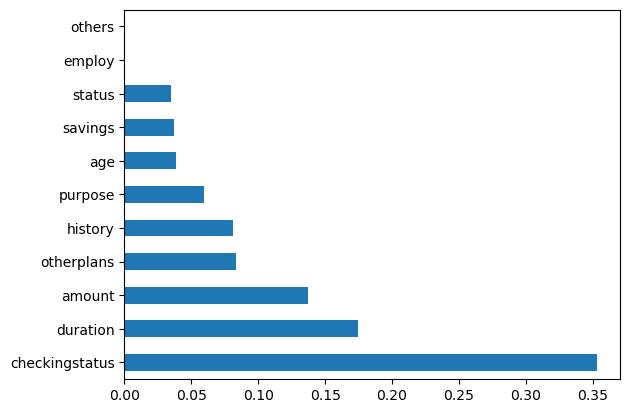

```python
from sklearn import tree

# entropy or gini
maxDepth = 5
clf = tree.DecisionTreeClassifier(max_depth= maxDepth, criterion= 'entropy')

Dtree= clf.fit(x_train,y_train)
prediction = Dtree.predict(x_test)

from sklearn import metrics
print(metrics.classification_report(y_test,prediction))
print(metrics.confusion_matrix(y_test,prediction))

F1_Score = metrics.f1_score(y_test, prediction, average='weighted')
print("Accuracy of the model on testing data is:", round(F1_Score,2))

%matplotlib inline
feature_importance = pd.Series(Dtree.feature_importances_, index=Predictors)
feature_importance.nlargest(11).plot(kind='barh')

from sklearn.model_selection import cross_val_score
Accuracy_Values = cross_val_score(Dtree,x,y,cv=10, scoring='f1_weighted')

print('final accuracy of the model is:', round(Accuracy_Values.mean(),2))
```

### Plotting a Decison Tree

```python
import os
os.environ['PATH'] += os.pathsep + "C:/Users/laksh/anaconda3/Anaconda3/Library/bin/Graphviz/bin/dot.exe"
```

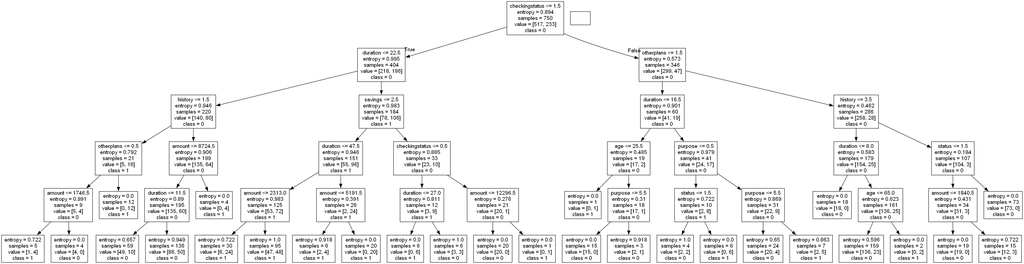

```python
from IPython.display import Image
from sklearn import tree
import pydotplus

dot_data = tree.export_graphviz(Dtree, out_file= None,
                               feature_names= Predictors, class_names= ['0','1'])

graph = pydotplus.graph_from_dot_data(dot_data)

Image(graph.create_png(), width=1500, height=2000)
```

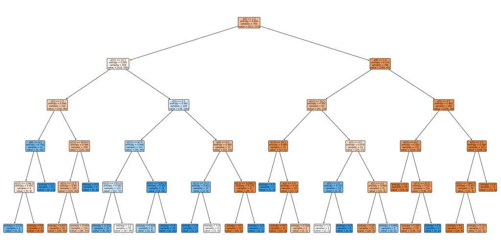

```python
import matplotlib.pyplot as plt
fig, axes = plt.subplots(nrows=1, ncols=1, figsize=(30,15))  # Increase the size
tree.plot_tree(Dtree, filled=True, rounded=True, ax=axes)
filename = "CreditRiskData_DTree_" + str(maxDepth) + ".png"
plt.savefig(filename, dpi=300)  # Increase the resolution
plt.show()
```